# Mendota_Modeling.Rmd

Lauren A. Knose, ORISE-EPA

2023-06-23

The purpose of this program is to perform an impact analysis comparing the internal vs external loading on changes in Chl-a and CyanoDensity.

# Step 1. Load dependent packages and data needed:

1. Loading dependent packages…

```r
library(ggplot2) #needed for plots
library(ggbreak) #needed for plot scale breaks
library(dplyr) #needed for reshaping/reformating data
library(rgl) #needed to make 3D plots
#library(xts) #needed to convert data frame to time series
```

2. Loading data… Note, ensure date data is formatted in R as Date.

```r
Me_algae<- read.csv(file="Cleaned_data/Mendota_Algae.csv") #read in the file with predictor variables
Me_algae<- Me_algae %>%
  mutate(sampledate=as.Date(sampledate, origin="1899-12-30"), #format as date
         X=NULL) #remove extra column
Me_extLoad<- read.csv(file="Cleaned_data/Mendota_P_allext.csv")
Me_extLoad<- Me_extLoad %>%
  mutate(sampledate=as.Date(sampledate, origin="1899-12-30"), #format as date
         X=NULL) #remove extra column
Me_intLoad<- read.csv(file="Cleaned_data/Mendota_P_water.csv")
Me_intLoad <- Me_intLoad %>%
  mutate(sampledate=as.Date(sampledate, origin="1899-12-30"), #format as date
         X=NULL) #remove extra column
```

# Step 2. Merge the data into one file:

Note, you can only merge two files at one time.

1. merging response and external loading data….

```r
Me_all<- merge(Me_algae, Me_extLoad, by="sampledate")
Me_all<- merge(Me_all, Me_intLoad, by="sampledate")
Me_all<- Me_all %>%
  mutate(Yr=Yr.x, #rename field
         Yr.x=NULL, #delete extra field
         daynum=daynum.x, #rename field
         daynum.x=NULL, #delete extra field
         Yr.y=NULL, #delete extra field
         daynum.y=NULL) #delete extra field
```

# Step 3. Calculate lagged data:

Note, Time series regression model assumes the time series “Y” has a linear relationship with the times series “X”. But, you need to subset the response variable(s) to the CyanoHAB season (daynum > 195 & < 255).To do this, I need to make a new time series with the current chl-a and the t-k, when k = 7, 14, 30.

creating a new data frame with lagged variables…

```r
water_int_k<- transform(Me_all, HE_ratio_k=lag(HE_ratio_TotP_mgL, n=7),
                        #adds column with X_1, t-7 value
                        totextP_kgday_k=lag(totextP_kgday, n=14),
                        #adds column with X_2, t-14 value
                        Chla_ugL_k=lag(Chla_ugL, n=7),
                        #adds column with Y_1, t-7 value
                        CyanoDens_cellsmL_k=lag(CyanoDens_cellsmL, n=7)
                        #adds column with Y_2, t-7 value
)
water_int_k<- water_int_k %>%
  filter(daynum < 255 & daynum > 195) #filters the data for the CyanoHAB season
```

Lagged data computed.

# Step 4. Check data for normality to determine whether transformation needed:

If data is normally distributed, then you can use simple linear regression or ANOVA. If data is non-normally distributed, then you need to pick a non-parametric model. The general linear model does not require normal-distribution.

checking for normality…

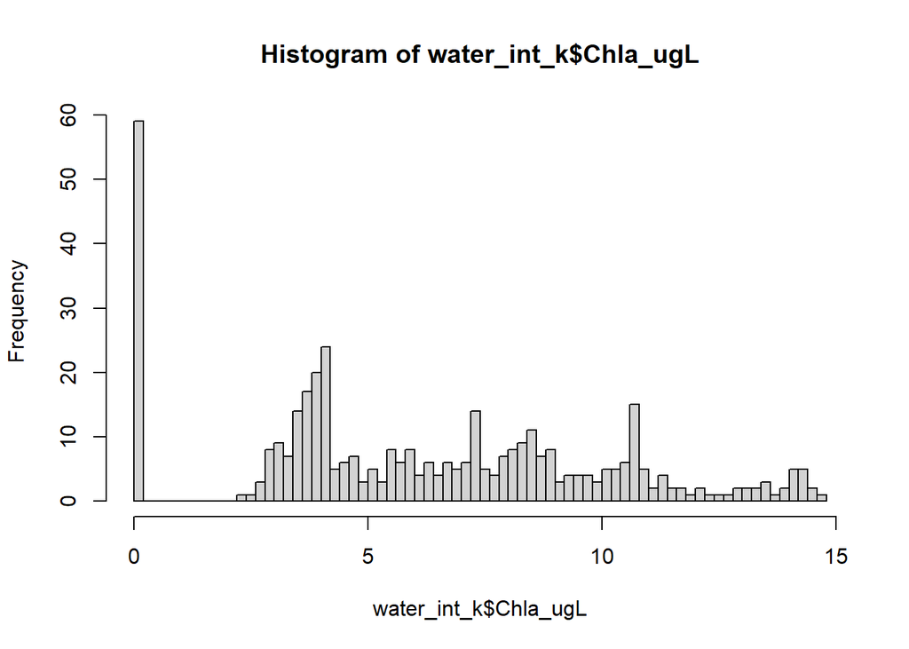

```r
hist(water_int_k$Chla_ugL, breaks=100) #prints histograph of Chl-a
```

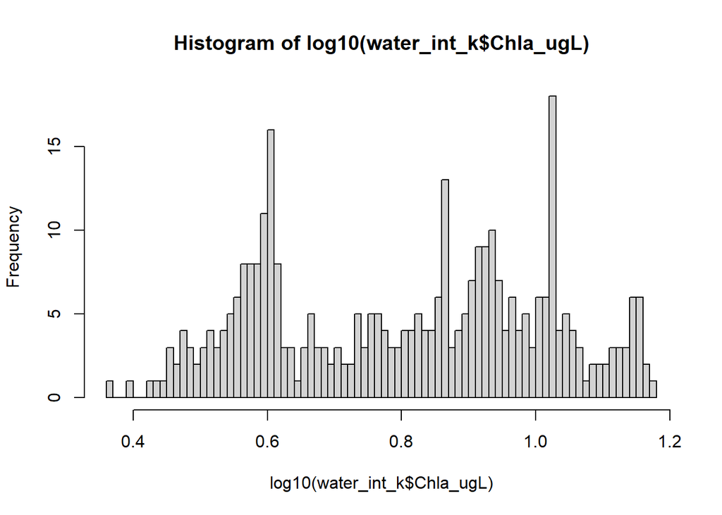

```r
#data right skewed
hist(log10(water_int_k$Chla_ugL), breaks=100) #prints histograph of log10(Chl-a)
```

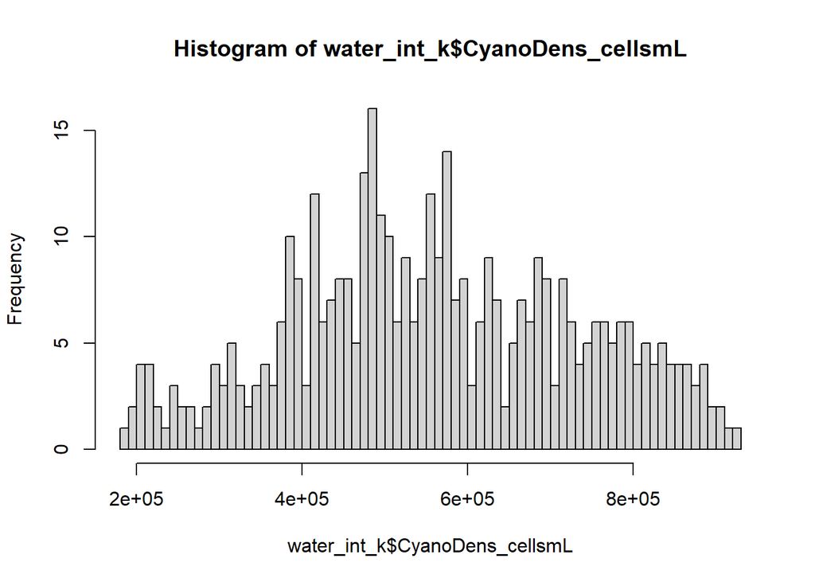

```r
#log-transform data is more normal
hist(water_int_k$CyanoDens_cellsmL, breaks=100) #prints histograph of CD
```

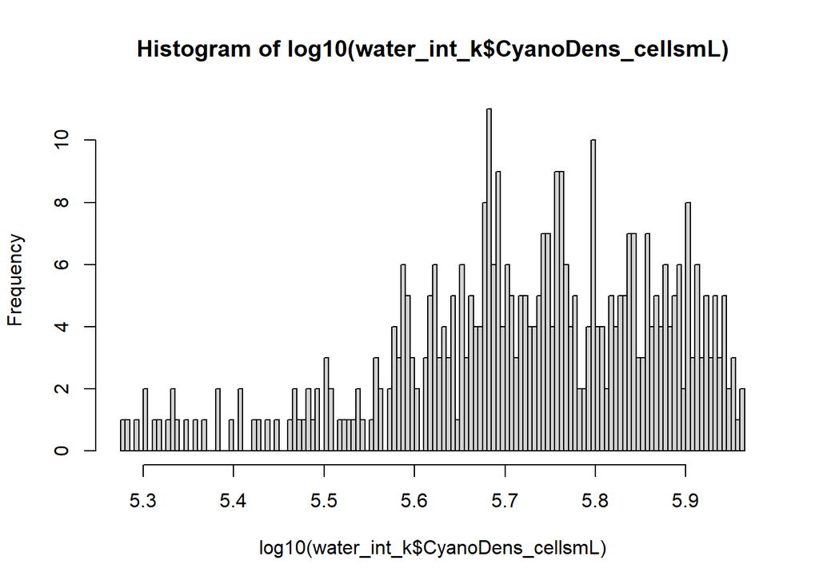

```r
#data right skewed
hist(log10(water_int_k$CyanoDens_cellsmL), breaks=100) #prints histograph of log10(CD)
```

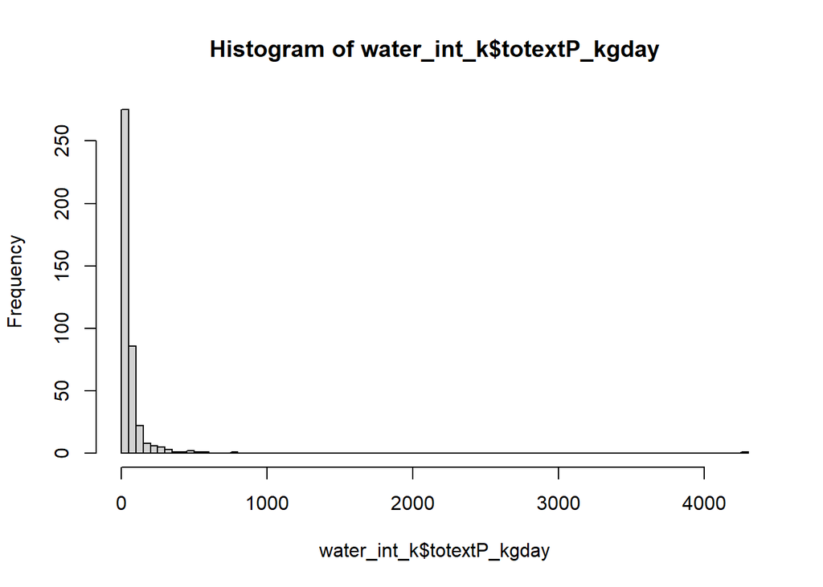

```r
#log-transform data is more normal
hist(water_int_k$totextP_kgday, breaks=100) #prints hist of ext load term
```

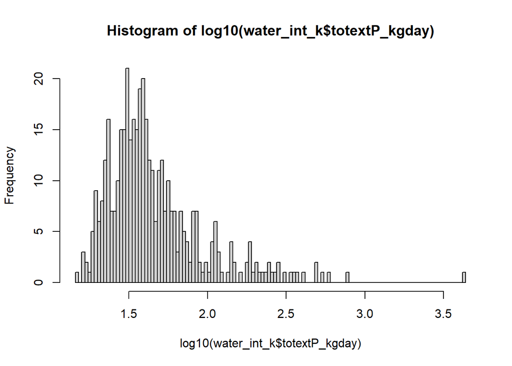

```r
#data right skewed
hist(log10(water_int_k$totextP_kgday), breaks=100) #prints hist of ext load term
```

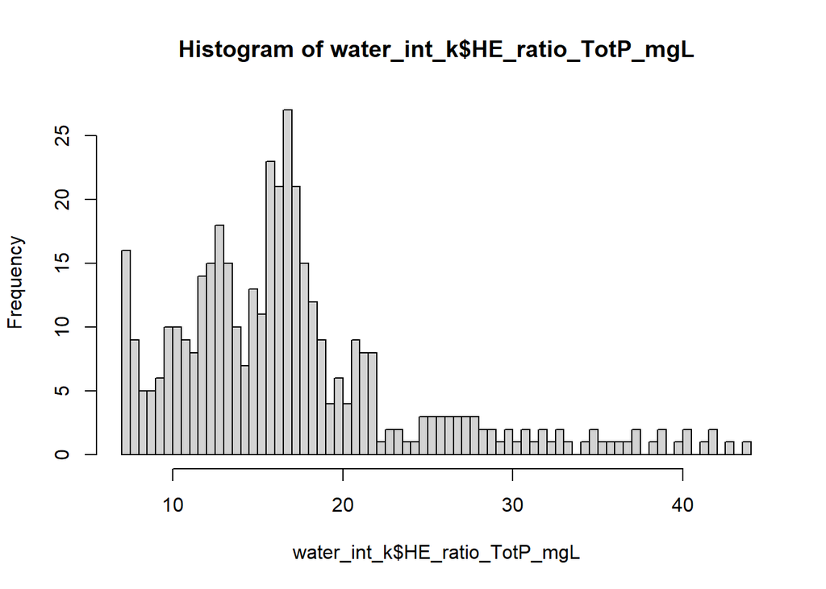

```r
#data more normal, but still right skewed
hist(water_int_k$HE_ratio_TotP_mgL, breaks=100) #prints hist of int load term
```

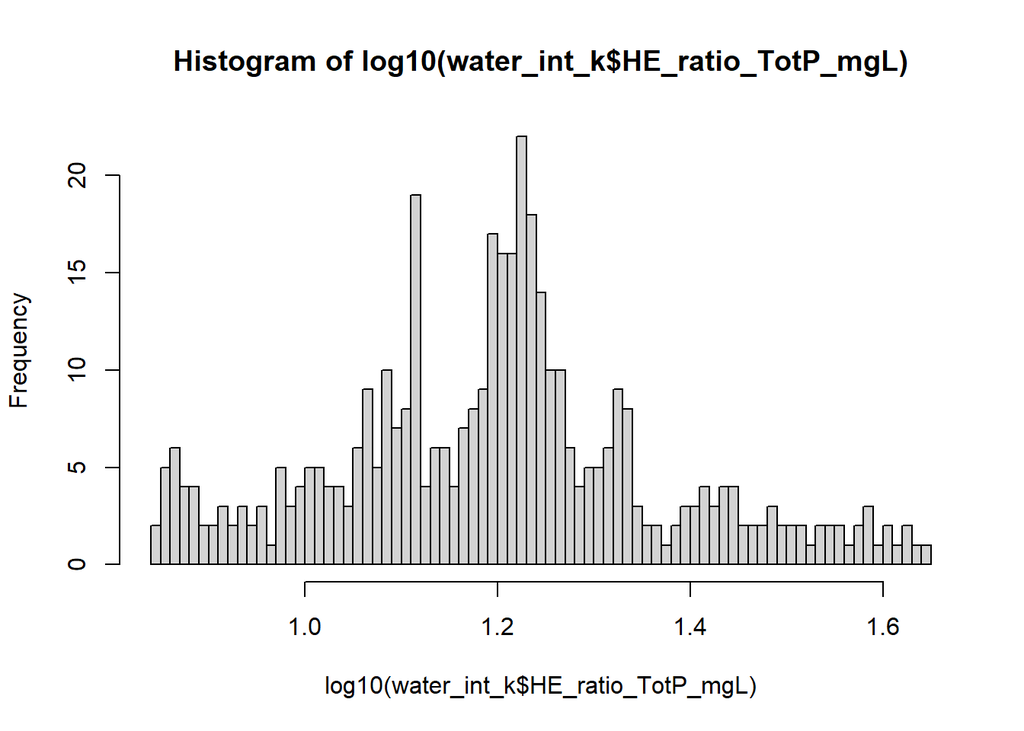

```r
#data right-skewed
hist(log10(water_int_k$HE_ratio_TotP_mgL), breaks=100) #prints hist of int load
```

```r
#data more normal
```

All data is positively skewed, so both predictor and response variables need to be transformed to log 10 for modeling.

# Step 5. Perform regression:

1. Run simplest model for each response variable…

Chla_t = Chla_t-7 + error…

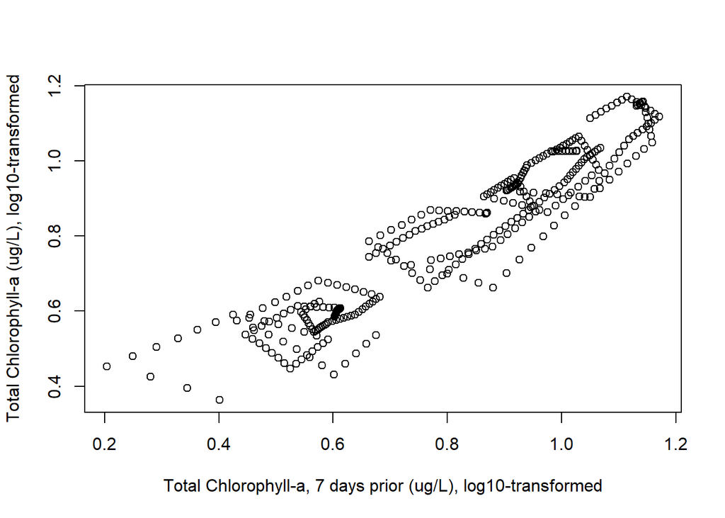

```r
plot(log10(water_int_k$Chla_ugL)~log10(water_int_k$Chla_ugL_k),
     xlab="Total Chlorophyll-a, 7 days prior (ug/L), log10-transformed",
     ylab="Total Chlorophyll-a (ug/L), log10-transformed")
```

```r
regk1_Chla<- glm(data=na.omit(water_int_k), #removes nas
            formula= log10(Chla_ugL+0.1)~log10(Chla_ugL_k+0.1)) #add 0.1 to avoid log10=NA
summary(regk1_Chla) #prints the glm output
```

```
##
## Call:
## glm(formula = log10(Chla_ugL + 0.1) ~ log10(Chla_ugL_k + 0.1),
##     data = na.omit(water_int_k))
##
## Deviance Residuals:
##      Min        1Q    Median        3Q       Max
## -0.19838  -0.03722  -0.01498   0.05230   0.24035
##
## Coefficients:
##                         Estimate Std. Error t value Pr(>|t|)
## (Intercept)             0.001515   0.004386   0.345     0.73
## log10(Chla_ugL_k + 0.1) 0.981796   0.005010 195.950   <2e-16 ***
## ---
## Signif. codes:  0 '***' 0.001 '**' 0.01 '*' 0.05 '.' 0.1 ' ' 1
##
## (Dispersion parameter for gaussian family taken to be 0.004650684)
##
##     Null deviance: 180.4816  on 412  degrees of freedom
## Residual deviance:   1.9114  on 411  degrees of freedom
## AIC: -1042.1
##
## Number of Fisher Scoring iterations: 2
```

```r
aov(regk1_Chla) #prints the sum of squares for the regression and residuals
```

```
## Call:
##    aov(formula = regk1_Chla)
##
## Terms:
##                 log10(Chla_ugL_k + 0.1) Residuals
## Sum of Squares                178.57018   1.91143
## Deg. of Freedom                       1       411
##
## Residual standard error: 0.06819592
## Estimated effects may be unbalanced
```

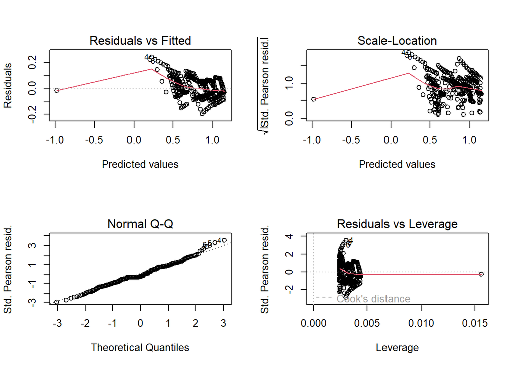

```r
layout(matrix(c(1,2,3,4),2,2)) # optional 4 graphs/page
plot(regk1_Chla) #prints diagnostic graphs for regression
```

```r
par(mfrow=c(1,1))#returns graphing viewer to 1 plot per page
```

CD_t = CD_t-7 + error…

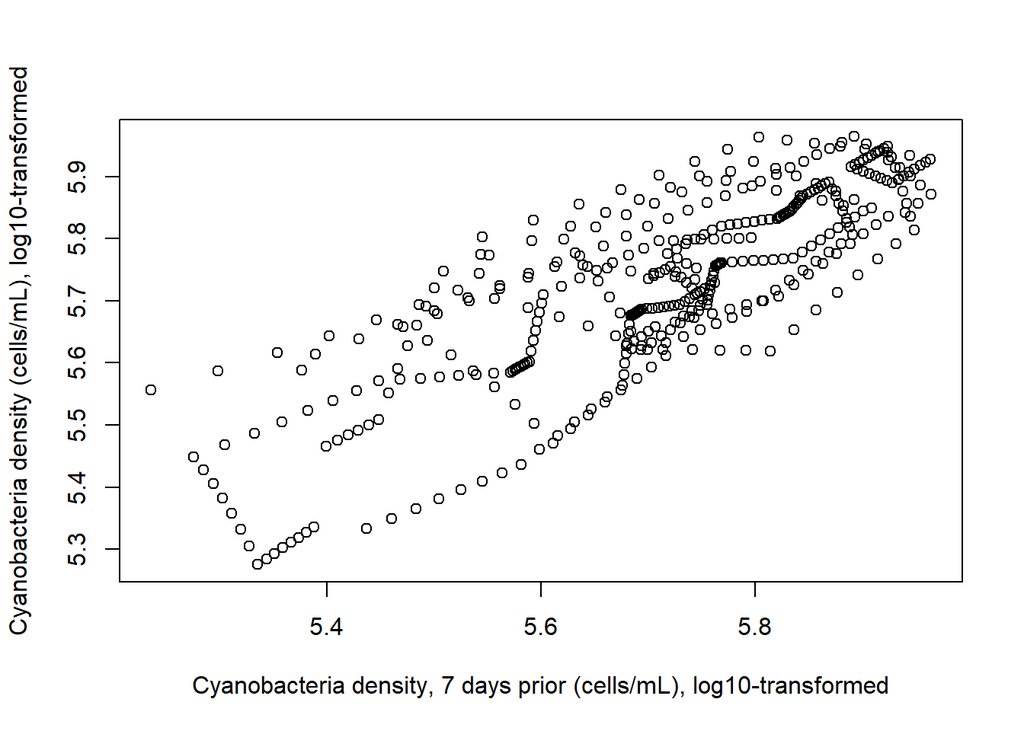

```r
plot(log10(water_int_k$CyanoDens_cellsmL)~log10(water_int_k$CyanoDens_cellsmL_k),
     xlab="Cyanobacteria density, 7 days prior (cells/mL), log10-transformed",
     ylab="Cyanobacteria density (cells/mL), log10-transformed")
```

```r
regk1_CD<- glm(data=na.omit(water_int_k),
            formula=log10(CyanoDens_cellsmL)~log10(CyanoDens_cellsmL_k)) #Y_2, t-k as predictor variable
summary(regk1_CD) #prints the glm output
```

```
##
## Call:
## glm(formula = log10(CyanoDens_cellsmL) ~ log10(CyanoDens_cellsmL_k),
##     data = na.omit(water_int_k))
##
## Deviance Residuals:
##      Min        1Q    Median        3Q       Max
## -0.19453  -0.05492   0.00176   0.05737   0.19857
##
## Coefficients:
##                            Estimate Std. Error t value Pr(>|t|)
## (Intercept)                 1.49389    0.15299   9.765   <2e-16 ***
## log10(CyanoDens_cellsmL_k)  0.74127    0.02678  27.676   <2e-16 ***
## ---
## Signif. codes:  0 '***' 0.001 '**' 0.01 '*' 0.05 '.' 0.1 ' ' 1
##
## (Dispersion parameter for gaussian family taken to be 0.007699199)
##
##     Null deviance: 9.0619  on 412  degrees of freedom
## Residual deviance: 3.1644  on 411  degrees of freedom
## AIC: -833.88
##
## Number of Fisher Scoring iterations: 2
```

```r
aov(regk1_CD)#prints the sum of squares for the regression and residuals
```

```
## Call:
##    aov(formula = regk1_CD)
##
## Terms:
##                 log10(CyanoDens_cellsmL_k) Residuals
## Sum of Squares                    5.897495  3.164371
## Deg. of Freedom                          1       411
##
## Residual standard error: 0.08774508
## Estimated effects may be unbalanced
```

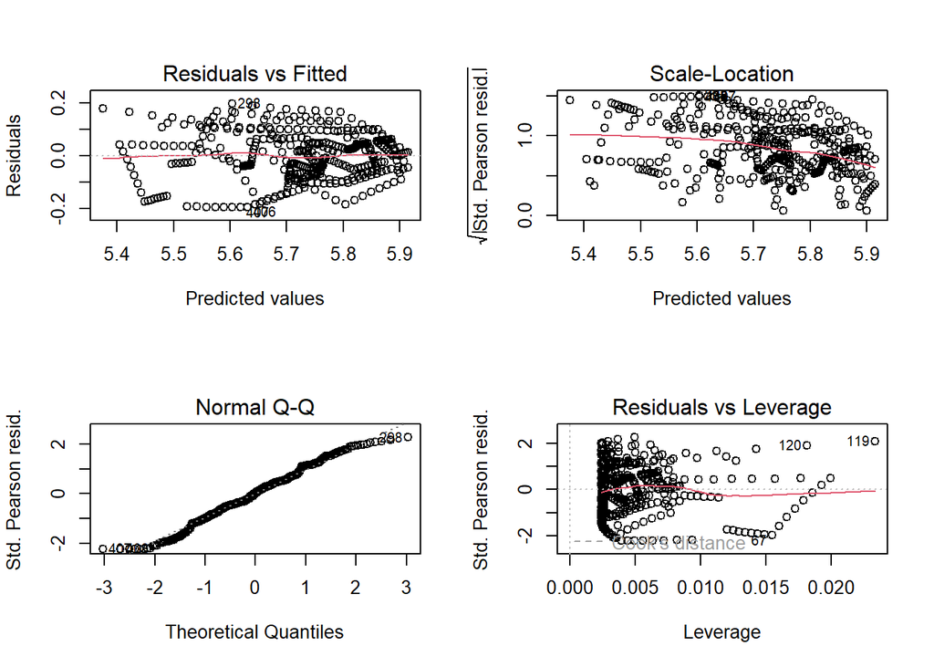

```r
layout(matrix(c(1,2,3,4),2,2)) # optional 4 graphs/page
plot(regk1_CD) #prints diagnostic graphs for regression
```

```r
par(mfrow=c(1,1))#returns graphing viewer to 1 plot per page
```

2. Run 2nd model for each response variable…

Chla_t = hypoP:epiP_t-7 + error…

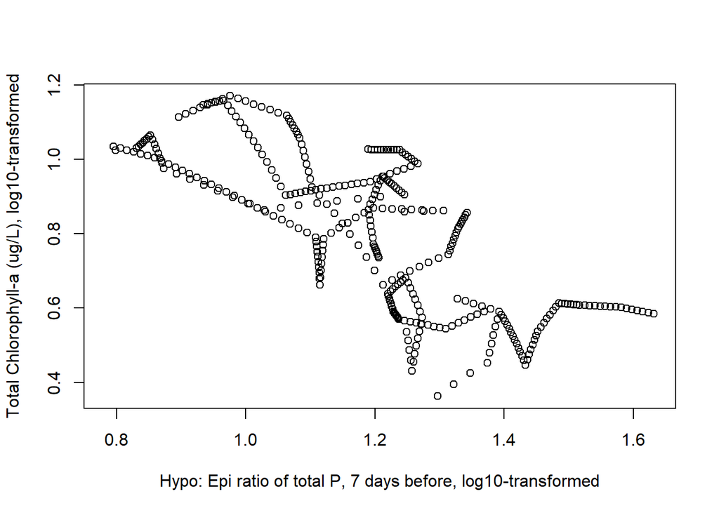

```r
plot(log10(water_int_k$Chla_ugL)~log10(water_int_k$HE_ratio_k),
     xlab="Hypo: Epi ratio of total P, 7 days before, log10-transformed",
     ylab="Total Chlorophyll-a (ug/L), log10-transformed")
```

```r
regk2_Chla<- glm(data=na.omit(water_int_k),
                 formula=log10(Chla_ugL+0.1)~log10(HE_ratio_k)) #X1 predictor variable
summary(regk2_Chla) #prints the glm output
```

```
##
## Call:
## glm(formula = log10(Chla_ugL + 0.1) ~ log10(HE_ratio_k), data = na.omit(water_int_k))
##
## Deviance Residuals:
##      Min        1Q    Median        3Q       Max
## -1.57853  -0.09629   0.19805   0.40339   0.70170
##
## Coefficients:
##                   Estimate Std. Error t value Pr(>|t|)
## (Intercept)        0.04106    0.20465   0.201   0.8411
## log10(HE_ratio_k)  0.44097    0.17339   2.543   0.0113 *
## ---
## Signif. codes:  0 '***' 0.001 '**' 0.01 '*' 0.05 '.' 0.1 ' ' 1
##
## (Dispersion parameter for gaussian family taken to be 0.4323243)
##
##     Null deviance: 180.48  on 412  degrees of freedom
## Residual deviance: 177.69  on 411  degrees of freedom
## AIC: 829.71
##
## Number of Fisher Scoring iterations: 2
```

```r
aov(regk2_Chla)#prints the sum of squares for the regression and residuals
```

```
## Call:
##    aov(formula = regk2_Chla)
##
## Terms:
##                 log10(HE_ratio_k) Residuals
## Sum of Squares            2.79633 177.68528
## Deg. of Freedom                 1       411
##
## Residual standard error: 0.6575137
## Estimated effects may be unbalanced
```

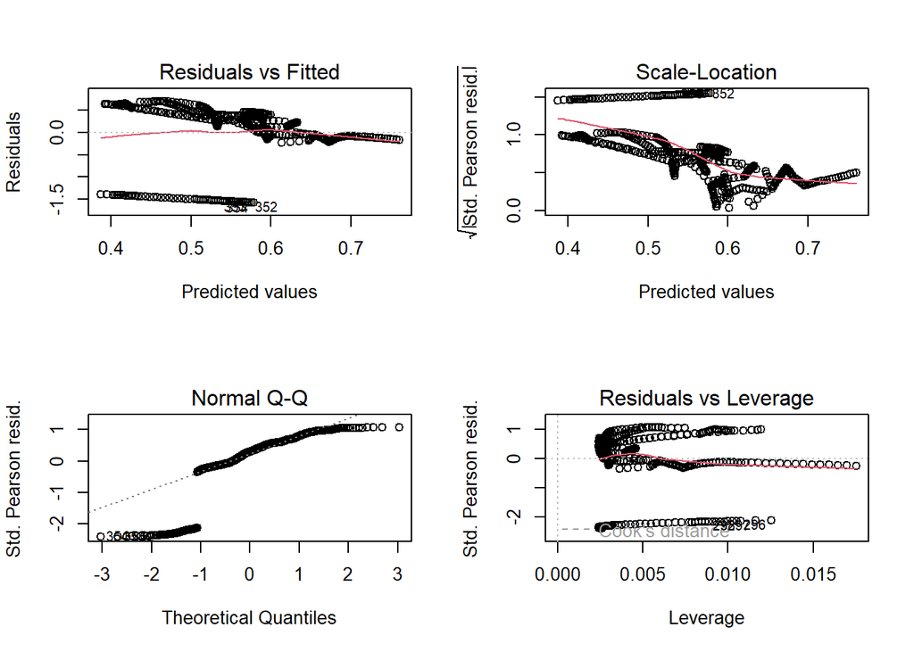

```r
layout(matrix(c(1,2,3,4),2,2)) # optional 4 graphs/page
plot(regk2_Chla) #prints diagnostic graphs for regression
```

```r
par(mfrow=c(1,1)) #returns graphing viewer to 1 plot per page
```

CD_t = hypoP:epiP_t-7 + error…

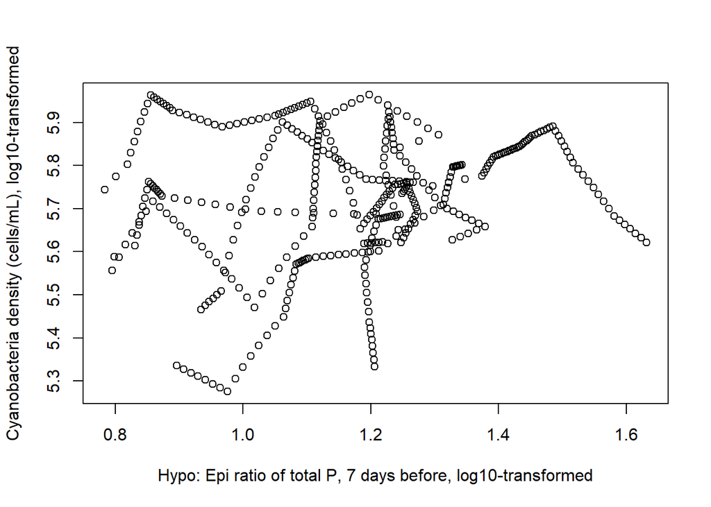

```r
plot(log10(water_int_k$CyanoDens_cellsmL)~log10(water_int_k$HE_ratio_k),
     xlab="Hypo: Epi ratio of total P, 7 days before, log10-transformed",
     ylab="Cyanobacteria density (cells/mL), log10-transformed")
```

```r
regk2_CD<- glm(data=water_int_k,
               formula=log10(CyanoDens_cellsmL)~log10(water_int_k$HE_ratio_k)) #X1 predictor variable
summary(regk2_CD) #prints the glm output
```

```
##
## Call:
## glm(formula = log10(CyanoDens_cellsmL) ~ log10(water_int_k$HE_ratio_k),
##     data = water_int_k)
##
## Deviance Residuals:
##      Min        1Q    Median        3Q       Max
## -0.42485  -0.08691   0.01586   0.09978   0.27942
##
## Coefficients:
##                               Estimate Std. Error t value Pr(>|t|)
## (Intercept)                    5.56709    0.04552 122.288  < 2e-16 ***
## log10(water_int_k$HE_ratio_k)  0.13674    0.03857   3.545 0.000438 ***
## ---
## Signif. codes:  0 '***' 0.001 '**' 0.01 '*' 0.05 '.' 0.1 ' ' 1
##
## (Dispersion parameter for gaussian family taken to be 0.02139416)
##
##     Null deviance: 9.0619  on 412  degrees of freedom
## Residual deviance: 8.7930  on 411  degrees of freedom
## AIC: -411.8
##
## Number of Fisher Scoring iterations: 2
```

```r
aov(regk2_CD)#prints the sum of squares for the regression and residuals
```

```
## Call:
##    aov(formula = regk2_CD)
##
## Terms:
##                 log10(water_int_k$HE_ratio_k) Residuals
## Sum of Squares                       0.268865  8.793001
## Deg. of Freedom                             1       411
##
## Residual standard error: 0.1462674
## Estimated effects may be unbalanced
```

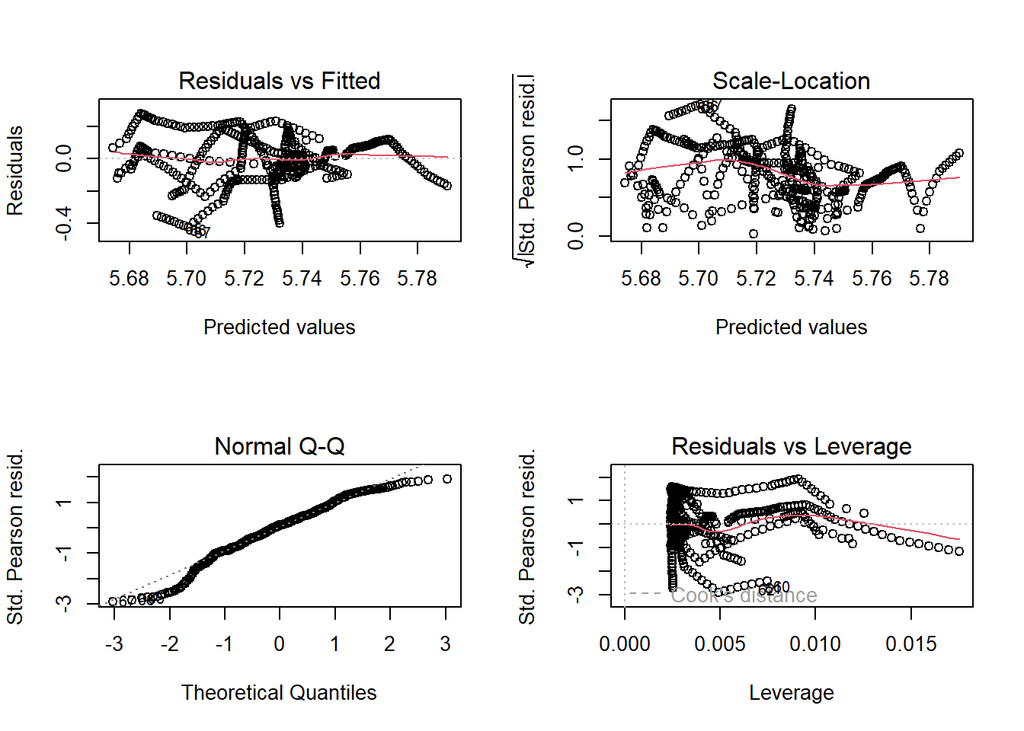

```r
layout(matrix(c(1,2,3,4),2,2)) # optional 4 graphs/page
plot(regk2_CD) #prints diagnostic graphs for regression
```

```r
par(mfrow=c(1,1)) #returns graphing viewer to 1 plot per page
```

3. Run 3rd model for each response variable…

Chla_t = ExtPLoad_t-14 + error…

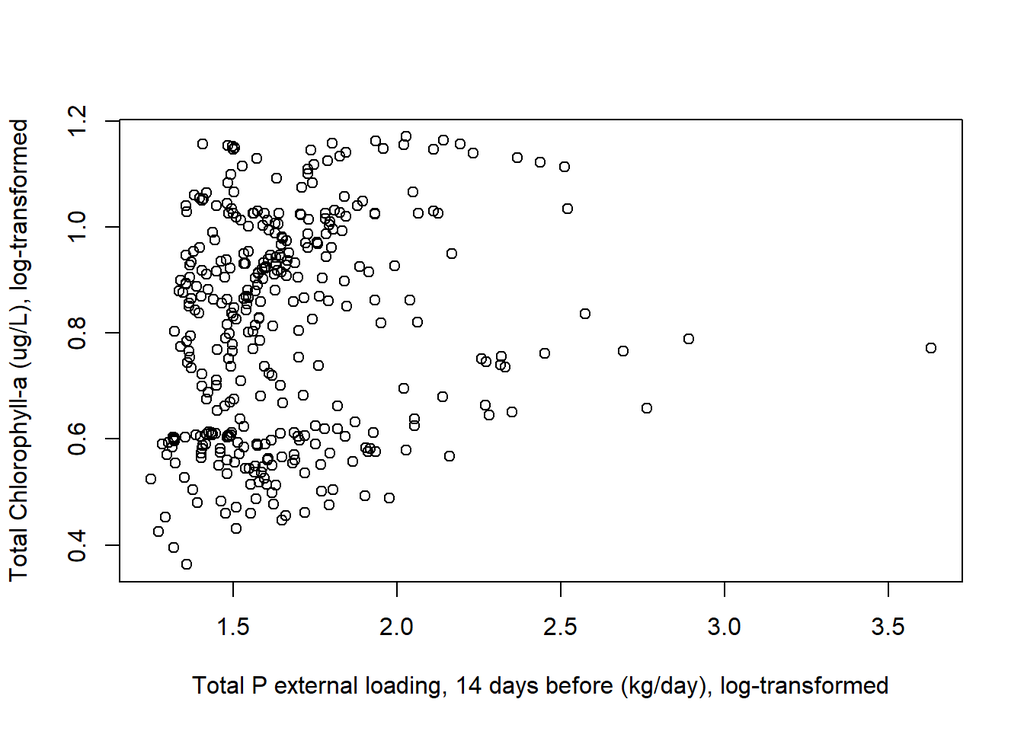

```r
plot(log10(water_int_k$Chla_ugL)~log10(water_int_k$totextP_kgday_k),
     xlab="Total P external loading, 14 days before (kg/day), log-transformed",
     ylab="Total Chlorophyll-a (ug/L), log-transformed")
```

```r
regk3_Chla<- glm(data=water_int_k,
            formula=log10(Chla_ugL+0.1)~log10(totextP_kgday_k))
summary(regk3_Chla) #prints the glm output
```

```
##
## Call:
## glm(formula = log10(Chla_ugL + 0.1) ~ log10(totextP_kgday_k),
##     data = water_int_k)
##
## Deviance Residuals:
##      Min        1Q    Median        3Q       Max
## -1.63111  -0.04025   0.20522   0.40284   0.86345
##
## Coefficients:
##                        Estimate Std. Error t value Pr(>|t|)
## (Intercept)              1.1047     0.1847   5.980 4.86e-09 ***
## log10(totextP_kgday_k)  -0.3278     0.1085  -3.022  0.00267 **
## ---
## Signif. codes:  0 '***' 0.001 '**' 0.01 '*' 0.05 '.' 0.1 ' ' 1
##
## (Dispersion parameter for gaussian family taken to be 0.4295835)
##
##     Null deviance: 180.48  on 412  degrees of freedom
## Residual deviance: 176.56  on 411  degrees of freedom
## AIC: 827.08
##
## Number of Fisher Scoring iterations: 2
```

```r
aov(regk3_Chla)#prints the sum of squares for the regression and residuals
```

```
## Call:
##    aov(formula = regk3_Chla)
##
## Terms:
##                 log10(totextP_kgday_k) Residuals
## Sum of Squares                  3.9228  176.5588
## Deg. of Freedom                      1       411
##
## Residual standard error: 0.6554262
## Estimated effects may be unbalanced
```

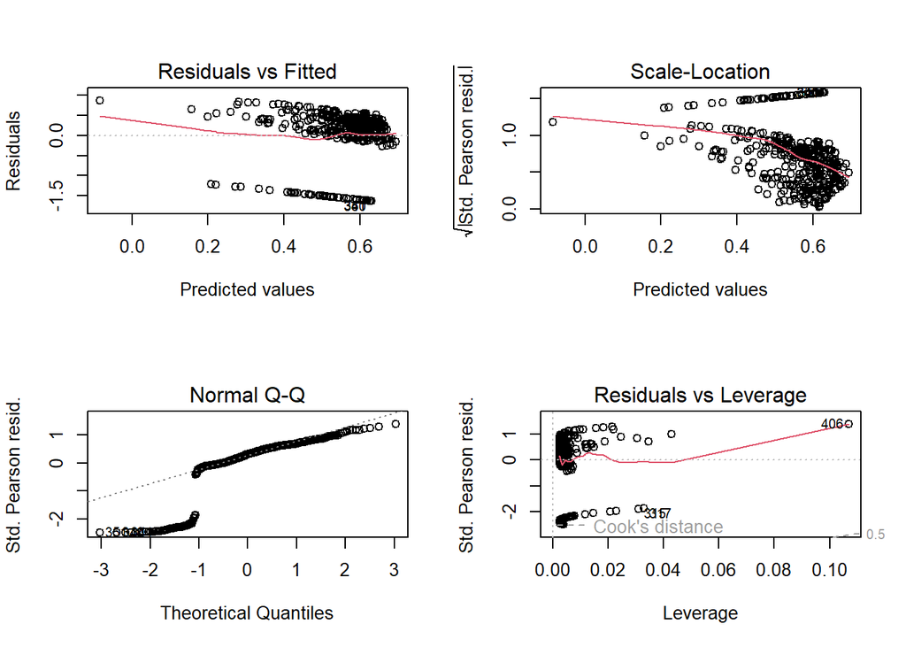

```r
layout(matrix(c(1,2,3,4),2,2)) # optional 4 graphs/page
plot(regk3_Chla) #prints diagnostic graphs for regression
```

```r
par(mfrow=c(1,1))
```

CD_t = ExtPLoad_t-14 + error…

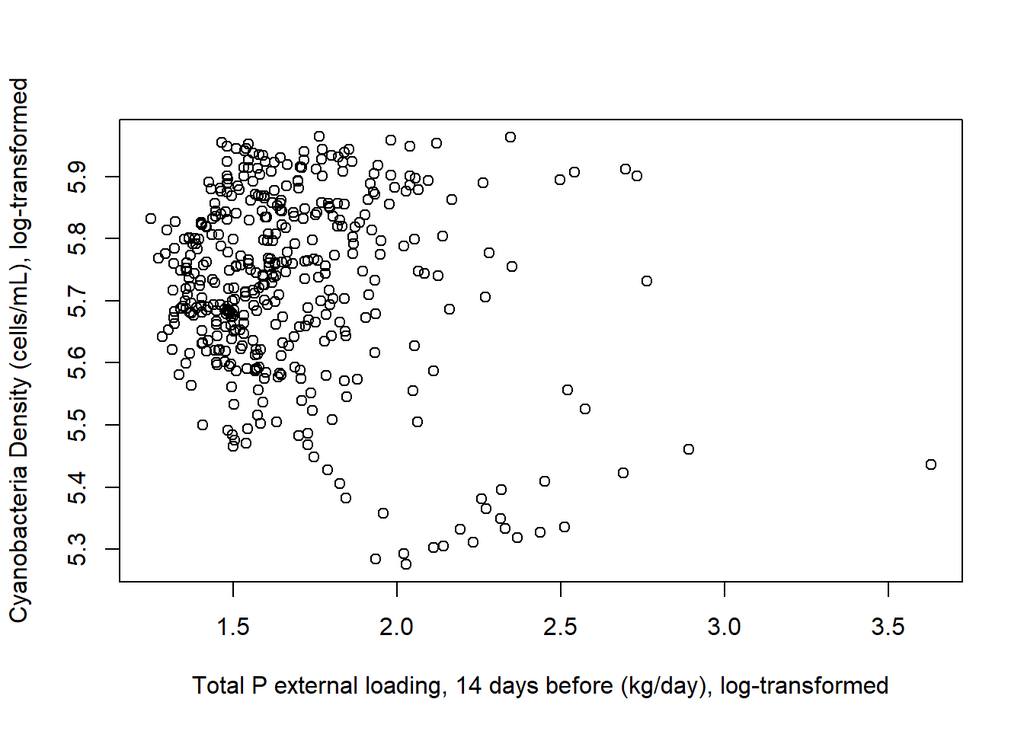

```r
plot(log10(water_int_k$CyanoDens_cellsmL)~log10(water_int_k$totextP_kgday_k),
     xlab="Total P external loading, 14 days before (kg/day), log-transformed",
     ylab="Cyanobacteria Density (cells/mL), log-transformed")
```

```r
regk3_CD<- glm(data=water_int_k,
            formula=log10(CyanoDens_cellsmL)~log10(totextP_kgday_k))
summary(regk3_CD)#prints the glm output
```

```
##
## Call:
## glm(formula = log10(CyanoDens_cellsmL) ~ log10(totextP_kgday_k),
##     data = water_int_k)
##
## Deviance Residuals:
##      Min        1Q    Median        3Q       Max
## -0.42027  -0.09014   0.00732   0.11599   0.29515
##
## Coefficients:
##                        Estimate Std. Error t value Pr(>|t|)
## (Intercept)             5.87177    0.04122 142.466  < 2e-16 ***
## log10(totextP_kgday_k) -0.08666    0.02420  -3.581 0.000383 ***
## ---
## Signif. codes:  0 '***' 0.001 '**' 0.01 '*' 0.05 '.' 0.1 ' ' 1
##
## (Dispersion parameter for gaussian family taken to be 0.02138129)
##
##     Null deviance: 9.0619  on 412  degrees of freedom
## Residual deviance: 8.7877  on 411  degrees of freedom
## AIC: -412.05
##
## Number of Fisher Scoring iterations: 2
```

```r
aov(regk3_CD)#prints the sum of squares for the regression and residuals
```

```
## Call:
##    aov(formula = regk3_CD)
##
## Terms:
##                 log10(totextP_kgday_k) Residuals
## Sum of Squares                0.274155  8.787711
## Deg. of Freedom                      1       411
##
## Residual standard error: 0.1462234
## Estimated effects may be unbalanced
```

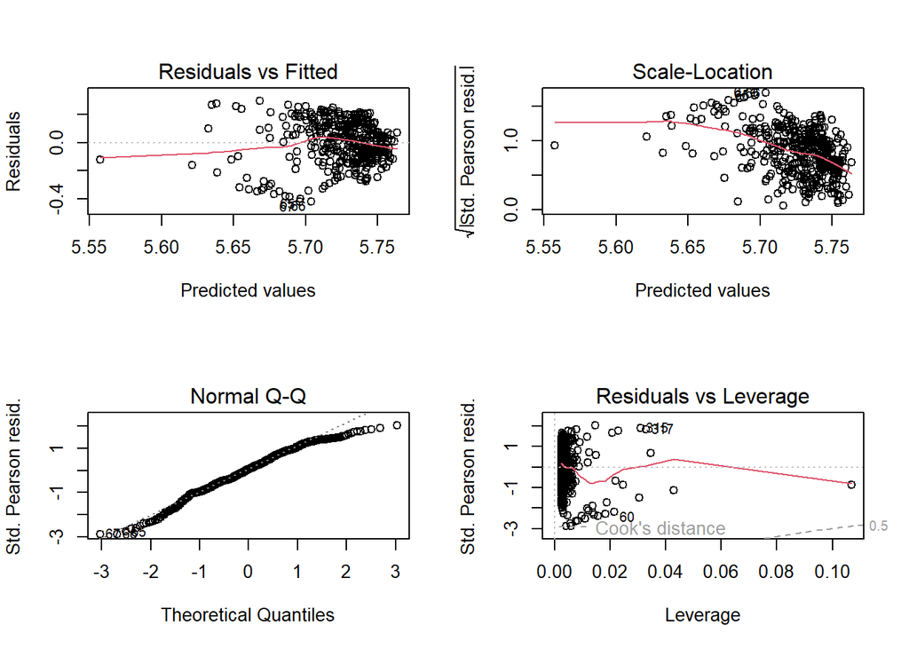

```r
layout(matrix(c(1,2,3,4),2,2)) # optional 4 graphs/page
plot(regk3_CD) #prints diagnostic graphs for regression
```

```r
par(mfrow=c(1,1))
```

4. Run 4th model for each response variable…

Chla_t = hypoP:epiP_t-7 + ExtPLoad_t-14 + error…

```r
regk4_Chla<- glm(formula=log10(Chla_ugL+0.1) ~ #response variable
             log10(HE_ratio_k) + #X1 predictor variable
              log10(totextP_kgday_k), #X2 predictor variable
              data=water_int_k) #data frame
summary(regk4_Chla)#prints the glm output
```

```
##
## Call:
## glm(formula = log10(Chla_ugL + 0.1) ~ log10(HE_ratio_k) + log10(totextP_kgday_k),
##     data = water_int_k)
##
## Deviance Residuals:
##     Min       1Q   Median       3Q      Max
## -1.6280  -0.1072   0.2022   0.4076   0.8682
##
## Coefficients:
##                        Estimate Std. Error t value Pr(>|t|)
## (Intercept)              0.6454     0.3287   1.963   0.0503 .
## log10(HE_ratio_k)        0.3067     0.1817   1.687   0.0923 .
## log10(totextP_kgday_k)  -0.2671     0.1141  -2.341   0.0197 *
## ---
## Signif. codes:  0 '***' 0.001 '**' 0.01 '*' 0.05 '.' 0.1 ' ' 1
##
## (Dispersion parameter for gaussian family taken to be 0.4276617)
##
##     Null deviance: 180.48  on 412  degrees of freedom
## Residual deviance: 175.34  on 410  degrees of freedom
## AIC: 826.22
##
## Number of Fisher Scoring iterations: 2
```

```r
aov(regk4_Chla)#prints the sum of squares for the regression and residuals
```

```
## Call:
##    aov(formula = regk4_Chla)
##
## Terms:
##                 log10(HE_ratio_k) log10(totextP_kgday_k) Residuals
## Sum of Squares            2.79633                2.34399 175.34128
## Deg. of Freedom                 1                      1       410
##
## Residual standard error: 0.6539585
## Estimated effects may be unbalanced
```

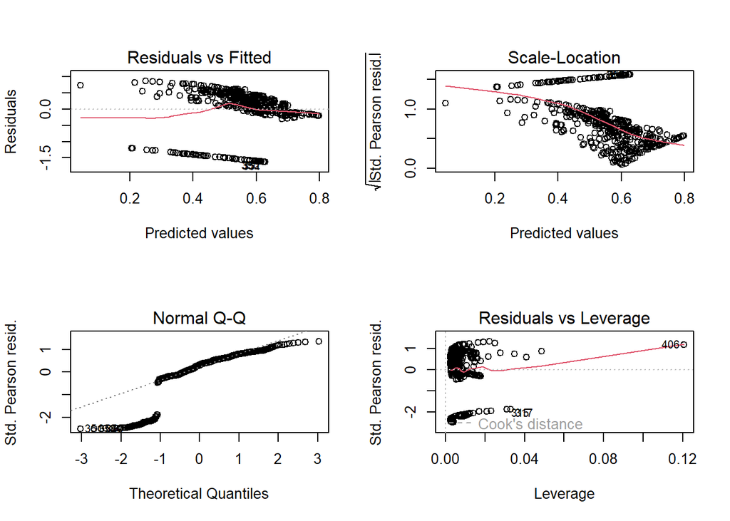

```r
layout(matrix(c(1,2,3,4),2,2)) # optional 4 graphs/page
plot(regk4_Chla) #prints diagnostic graphs for regression
```

```r
par(mfrow=c(1,1))
```

CD_t = hypoP:epiP_t-7 + ExtPLoad_t-14 + error…

```r
regk4_CD<- glm(formula=log10(CyanoDens_cellsmL) ~ #response variable
             log10(HE_ratio_k) + #X1 predictor variable
              log10(totextP_kgday_k), #X2 predictor variable
              data=water_int_k) #data frame
summary(regk4_CD)
```

```
##
## Call:
## glm(formula = log10(CyanoDens_cellsmL) ~ log10(HE_ratio_k) +
##     log10(totextP_kgday_k), data = water_int_k)
##
## Deviance Residuals:
##      Min        1Q    Median        3Q       Max
## -0.40789  -0.09100   0.00886   0.10496   0.31346
##
## Coefficients:
##                        Estimate Std. Error t value Pr(>|t|)
## (Intercept)             5.71682    0.07301  78.301  < 2e-16 ***
## log10(HE_ratio_k)       0.10346    0.04036   2.563  0.01073 *
## log10(totextP_kgday_k) -0.06616    0.02534  -2.612  0.00934 **
## ---
## Signif. codes:  0 '***' 0.001 '**' 0.01 '*' 0.05 '.' 0.1 ' ' 1
##
## (Dispersion parameter for gaussian family taken to be 0.02109543)
##
##     Null deviance: 9.0619  on 412  degrees of freedom
## Residual deviance: 8.6491  on 410  degrees of freedom
## AIC: -416.61
##
## Number of Fisher Scoring iterations: 2
```

```r
aov(regk4_CD)
```

```
## Call:
##    aov(formula = regk4_CD)
##
## Terms:
##                 log10(HE_ratio_k) log10(totextP_kgday_k) Residuals
## Sum of Squares           0.268865               0.143875  8.649126
## Deg. of Freedom                 1                      1       410
##
## Residual standard error: 0.1452427
## Estimated effects may be unbalanced
```

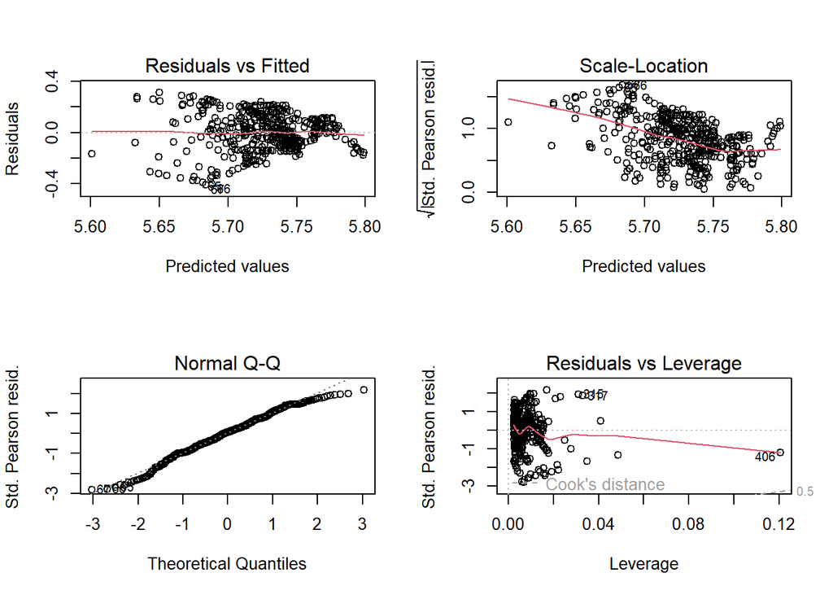

```r
layout(matrix(c(1,2,3,4),2,2)) # optional 4 graphs/page
plot(regk4_CD) #prints diagnostic graphs for regression
```

```r
par(mfrow=c(1,1))
```

5. Run 5th model for each response variable…

Chla_t = hypoP:epiP_t-7 + ExtPLoad_t-14 + Chla_t-7 + error…

```r
regk5_Chla<- glm(formula=log10(Chla_ugL+0.1) ~ #response variable
             log10(HE_ratio_k) + #X1 predictor variable
              log10(totextP_kgday_k) +
               log10(Chla_ugL_k+0.1), #X2 predictor variable
              data=water_int_k) #data frame
summary(regk5_Chla)#prints the glm output
```

```
##
## Call:
## glm(formula = log10(Chla_ugL + 0.1) ~ log10(HE_ratio_k) + log10(totextP_kgday_k) +
##     log10(Chla_ugL_k + 0.1), data = water_int_k)
##
## Deviance Residuals:
##       Min         1Q     Median         3Q        Max
## -0.206370  -0.038911  -0.000886   0.044630   0.211599
##
## Coefficients:
##                          Estimate Std. Error t value Pr(>|t|)
## (Intercept)             -0.052478   0.033114  -1.585   0.1138
## log10(HE_ratio_k)        0.084877   0.018240   4.653 4.42e-06 ***
## log10(totextP_kgday_k)  -0.025521   0.011490  -2.221   0.0269 *
## log10(Chla_ugL_k + 0.1)  0.978015   0.004863 201.110  < 2e-16 ***
## ---
## Signif. codes:  0 '***' 0.001 '**' 0.01 '*' 0.05 '.' 0.1 ' ' 1
##
## (Dispersion parameter for gaussian family taken to be 0.004291865)
##
##     Null deviance: 180.4816  on 412  degrees of freedom
## Residual deviance:   1.7554  on 409  degrees of freedom
## AIC: -1073.3
##
## Number of Fisher Scoring iterations: 2
```

```r
aov(regk5_Chla)#prints the sum of squares for the regression and residuals
```

```
## Call:
##    aov(formula = regk5_Chla)
##
## Terms:
##                 log10(HE_ratio_k) log10(totextP_kgday_k)
## Sum of Squares            2.79633                2.34399
## Deg. of Freedom                 1                      1
##                 log10(Chla_ugL_k + 0.1) Residuals
## Sum of Squares                173.58591   1.75537
## Deg. of Freedom                       1       409
##
## Residual standard error: 0.06551233
## Estimated effects may be unbalanced
```

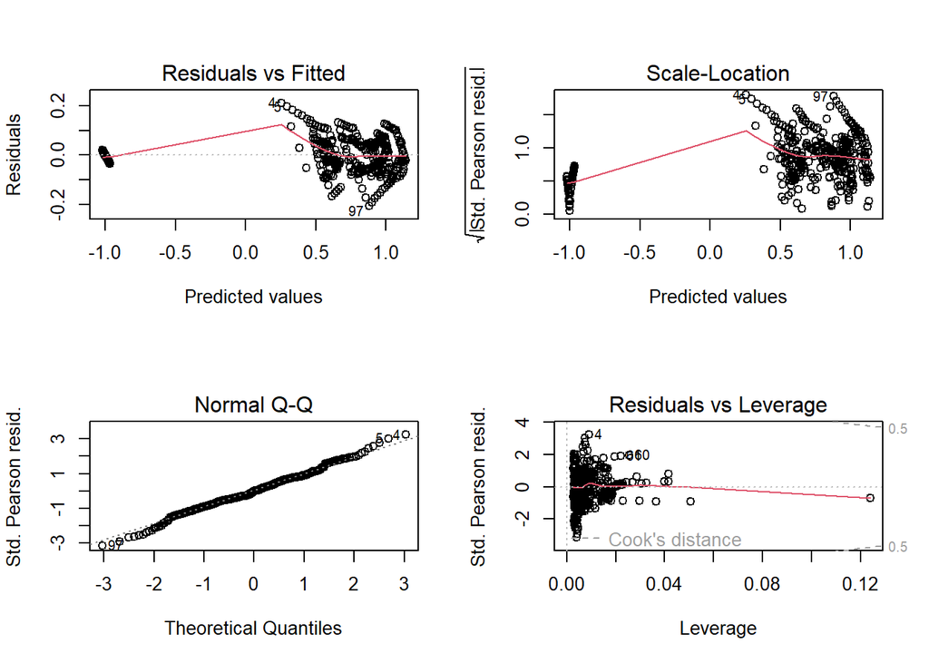

```r
layout(matrix(c(1,2,3,4),2,2)) # optional 4 graphs/page
plot(regk5_Chla) #prints diagnostic graphs for regression
```

```r
par(mfrow=c(1,1))
```

CD_t = hypoP:epiP_t-7 + ExtPLoad_t-14 + CD_t-7 + error…

```r
regk5_CD<- glm(formula=log10(CyanoDens_cellsmL) ~ #response variable
             log10(HE_ratio_k) + #X1 predictor variable
              log10(totextP_kgday_k) +
               log10(CyanoDens_cellsmL_k), #X2 predictor variable
              data=water_int_k) #data frame
summary(regk5_CD)
```

```
##
## Call:
## glm(formula = log10(CyanoDens_cellsmL) ~ log10(HE_ratio_k) +
##     log10(totextP_kgday_k) + log10(CyanoDens_cellsmL_k), data = water_int_k)
##
## Deviance Residuals:
##       Min         1Q     Median         3Q        Max
## -0.207104  -0.054358  -0.000816   0.065771   0.190334
##
## Coefficients:
##                            Estimate Std. Error t value Pr(>|t|)
## (Intercept)                 1.41116    0.15466   9.124  < 2e-16 ***
## log10(HE_ratio_k)          -0.16612    0.02497  -6.654 9.19e-11 ***
## log10(totextP_kgday_k)     -0.04827    0.01455  -3.318 0.000989 ***
## log10(CyanoDens_cellsmL_k)  0.80384    0.02780  28.920  < 2e-16 ***
## ---
## Signif. codes:  0 '***' 0.001 '**' 0.01 '*' 0.05 '.' 0.1 ' ' 1
##
## (Dispersion parameter for gaussian family taken to be 0.006944976)
##
##     Null deviance: 9.0619  on 412  degrees of freedom
## Residual deviance: 2.8405  on 409  degrees of freedom
## AIC: -874.48
##
## Number of Fisher Scoring iterations: 2
```

```r
aov(regk5_CD)
```

```
## Call:
##    aov(formula = regk5_CD)
##
## Terms:
##                 log10(HE_ratio_k) log10(totextP_kgday_k)
## Sum of Squares           0.268865               0.143875
## Deg. of Freedom                 1                      1
##                 log10(CyanoDens_cellsmL_k) Residuals
## Sum of Squares                    5.808631  2.840495
## Deg. of Freedom                          1       409
##
## Residual standard error: 0.08333652
## Estimated effects may be unbalanced
```

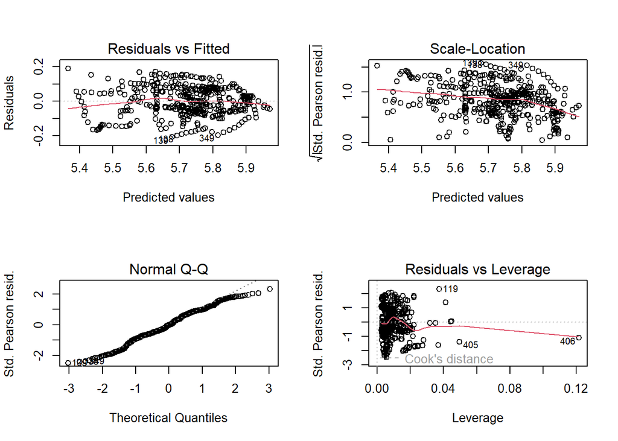

```r
layout(matrix(c(1,2,3,4),2,2)) # optional 4 graphs/page
plot(regk5_CD) #prints diagnostic graphs for regression
```

```r
par(mfrow=c(1,1))
```

# Step 6. Compare the models:

The model with the lowest AIC, Residual standard error, and each term is significant (t-score p-valu < 0.05) is the best model.

# Step 7. Compare the output by year:

```r
regk5_Chla<- glm(formula=log10(Chla_ugL+0.1) ~ #response variable
             log10(HE_ratio_k) + #X1 predictor variable
              log10(totextP_kgday_k) +#x2 predictor variable
               log10(Chla_ugL_k+0.1), #X3 predctor variable
              data=subset(water_int_k, Yr==2018) #data from year z
             )
aov(regk5_Chla)#prints the sum of squares for the regression and residuals
```

```
## Call:
##    aov(formula = regk5_Chla)
##
## Terms:
##                 log10(HE_ratio_k) log10(totextP_kgday_k)
## Sum of Squares         0.27133701             0.10526811
## Deg. of Freedom                 1                      1
##                 log10(Chla_ugL_k + 0.1)  Residuals
## Sum of Squares               0.00549632 0.11449349
## Deg. of Freedom                       1         55
##
## Residual standard error: 0.04562565
## Estimated effects may be unbalanced
```

```r
regk5_CD<- glm(formula=log10(CyanoDens_cellsmL) ~ #response variable
             log10(HE_ratio_k) + #X1 predictor variable
              log10(totextP_kgday_k) +
               log10(CyanoDens_cellsmL_k), #X2 predictor variable
              data=subset(water_int_k, Yr==2018) #data frame
            )
aov(regk5_CD)
```

```
## Call:
##    aov(formula = regk5_CD)
##
## Terms:
##                 log10(HE_ratio_k) log10(totextP_kgday_k)
## Sum of Squares          0.2189584              0.3308278
## Deg. of Freedom                 1                      1
##                 log10(CyanoDens_cellsmL_k) Residuals
## Sum of Squares                   0.1387747 0.1203522
## Deg. of Freedom                          1        55
##
## Residual standard error: 0.04677844
## Estimated effects may be unbalanced
```

# Step 8. Making a 3D plot of the selected model:

```r
mycols <- colorRampPalette( c("green", "red") )
plot3d(
  x=log10(water_int_k$HE_ratio_k),
  y=water_int_k$totextP_kgday_k,
  z=(water_int_k$Chla_ugL),
  colvar=(water_int_k$Chla_ugL),
  type = 's',
  size=0.75,
  xlab="Hypo: Epi P ratio",
  ylab="Total P external load (lb/day)",
  zlab="Total Chl-a from 7 days before (ug/L)")
rglwidget()
```

[interactive chart not shown]